# Consumer Behaviour

Francis Ngema

2024-06-07

# Introduction

The purpose of this exploratory data analysis was to understand the distribution of variables in the rice dataset, identify any patterns or trends, and gain insights into factors influencing customer decisions regarding certified rice. This analysis was intended to guide further studies using the Random Forest algorithm to understand customer behavior patterns and identify key determinants of consumer behavior.

# Methodology

## Exploratory Data Analysis

### Data Import and Initial Inspection

The rice dataset was imported from an Excel file. Initial inspection of the dataset included examining the structure and summary statistics of the variables.

```r
# Import the dataset
data <- read_excel("rice_dataset.xlsx")

# Display the first few rows of the dataset
head(data)
```

```
## # A tibble: 6 × 19
##      ID   Age Gender   Inc   Edu Child  Hhsz   Buy   Kno Compt  Sens Health
##   <dbl> <dbl>  <dbl> <dbl> <dbl> <dbl> <dbl> <dbl> <dbl> <dbl> <dbl>  <dbl>
## 1     1    34      1     0     5     1     4     1     1  5     6.25   6.33
## 2     2    41      1     0     2     1     3     1     0  4.67  6      6.33
## 3     3    49      1     1     5     1    10     1     0  5.33  5.5    5
## 4     4    47      1     0     2     1     4     1     0  4.67  6.25   6
## 5     5    59      1     0     4     1     3     1     1  4.67  5.75   4.67
## 6     6    34      1     0     4     1     3     0     1  3.33  6.25   6.33
## # ℹ 7 more variables: Conve <dbl>, Price <dbl>, Lresi <dbl>, Trust <dbl>,
## #   Env <dbl>, Read <dbl>, Cons <dbl>
```

### Data Description

The rice dataset (available at https://data.mendeley.com/datasets/38w64m7w7t/1) comprises information gathered from participants, focusing on their demographic characteristics, beliefs, and behaviors related to certified rice consumption. Key variables include age, gender, education level, income class, household size, purchase behavior of certified rice, objective knowledge of food quality certifications, perceived competence in identifying certified rice, beliefs regarding sensory appeal, health benefits, convenience, value for money, and environmental consequences of certified rice.

Furthermore, variables capture participants’ trust in food quality certification systems, reading habits of food labels, and the importance of rice in their overall diet. Overall, the dataset provides a comprehensive snapshot of participants’ attitudes and behaviors regarding certified rice consumption, facilitating further analysis to uncover patterns and insights influencing consumer decisions in this domain.

*Table 1*

| Variable | Description | Variable type |
| --- | --- | --- |
| ID | Participant ID | Numeric, continuous |
| Age | Age of the participant | Numeric, continuous |
| Gender | Gender of the participant | Binary |
| Inc | Self-reported income class of the participant | Binary |
| Edu | Education of the participant | Categorical |
| Child | Having children under 15 years of age | Binary |
| Hhsz | Number of household members | Numeric, continuous |
| Buy | Participant’s purchase behavior of certified rice | Binary |
| Kno | Objective knowledge of food quality certifications for rice | Binary |
| Compt | Perceived self-competence in identifying certified rice | Categorical |
| Sens | Belief in the sensory appeal of certified rice | Categorical |
| Health | Belief in the health benefits of certified rice | Categorical |
| Conve | Belief in the convenience benefits of certified rice | Categorical |
| Price | Belief that certified rice is good value for money | Categorical |
| Lresi | Belief that certified rice has much less residues compared to conventional rice | Binary |
| Trust | Trust in the food quality certification system for rice | Binary |
| Env | Perceived psychological consequences of environmentally friendly behavior | Categorical |
| Read | Reading of food labels while purchasing food | Binary |
| Cons | Importance of the food product as a staple within participant’s overall diet | Binary |

This table provides a concise overview of the variables in the dataset, their descriptions, and variable types.

### Data Exploration and Visualization

We conducted univariate analysis to explore the distribution of individual variables. Numeric variables such as Age and Household Size (`Hhsz`) were visualized using histograms. Categorical variables, including `Gender`, Income Class (`Inc`), Education Level (`Edu`), and others, were visualised using bar plots.

Bivariate analysis was performed to examine relationships between pairs of variables. This included scatter plots to analyse relationships between numeric variables. Furthermore, box plots were utilised to explore the relationship between numeric and categorical variables.

A correlation matrix for the numeric variables Age and Household Size (`Hhsz`) was computed and visualised to understand the relationships between these variables.

### Summary Statistics

Upon inspecting the summary statistics of the rice dataset, it was observed that some variables had missing values. The summary below provides a glimpse into the distribution of variables, highlighting the presence of missing values where applicable.

[output not shown]

It can be noted below that the `Sens`, `Conve`, `Health` and `Price` variables have missing values.`Health` has two missing values, and `Sens`, `Conve` and `Price` have one missing value each.

```r
# Display the structure of the dataset
str(data)
```

```
## tibble [199 × 19] (S3: tbl_df/tbl/data.frame)
##  $ ID    : num [1:199] 1 2 3 4 5 6 7 8 9 10 ...
##  $ Age   : num [1:199] 34 41 49 47 59 34 43 54 53 52 ...
##  $ Gender: num [1:199] 1 1 1 1 1 1 1 1 1 0 ...
##  $ Inc   : num [1:199] 0 0 1 0 0 0 1 0 1 1 ...
##  $ Edu   : num [1:199] 5 2 5 2 4 4 2 2 4 2 ...
##  $ Child : num [1:199] 1 1 1 1 1 1 1 0 1 1 ...
##  $ Hhsz  : num [1:199] 4 3 10 4 3 3 7 3 4 7 ...
##  $ Buy   : num [1:199] 1 1 1 1 1 0 1 1 1 0 ...
##  $ Kno   : num [1:199] 1 0 0 0 1 1 1 1 0 1 ...
##  $ Compt : num [1:199] 5 4.67 5.33 4.67 4.67 3.33 6.33 5.67 4 4.67 ...
##  $ Sens  : num [1:199] 6.25 6 5.5 6.25 5.75 6.25 6.25 6.25 5.5 5 ...
##  $ Health: num [1:199] 6.33 6.33 5 6 4.67 6.33 6.67 6.33 6 6.67 ...
##  $ Conve : num [1:199] 6 4 5 4.33 3.67 4 5 5.67 5 5.33 ...
##  $ Price : num [1:199] 6 6 6 6 5 4 4 6 6 5 ...
##  $ Lresi : num [1:199] 1 1 0 1 0 0 0 1 1 1 ...
##  $ Trust : num [1:199] 0 0 0 0 0 0 1 0 0 0 ...
##  $ Env   : num [1:199] 6.33 7 6 6.67 6 7 6.67 6 7 6.33 ...
##  $ Read  : num [1:199] 1 1 1 1 1 1 1 0 1 1 ...
##  $ Cons  : num [1:199] 1 1 1 1 1 1 1 1 1 1 ...
```

```r
# Glimpse of the dataset
glimpse(data)
```

```
## Rows: 199
## Columns: 19
## $ ID     <dbl> 1, 2, 3, 4, 5, 6, 7, 8, 9, 10, 11, 12, 13, 14, 15, 16, 17, 18, …
## $ Age    <dbl> 34, 41, 49, 47, 59, 34, 43, 54, 53, 52, 50, 29, 26, 59, 31, 26,…
## $ Gender <dbl> 1, 1, 1, 1, 1, 1, 1, 1, 1, 0, 1, 1, 1, 0, 1, 1, 1, 1, 1, 1, 1, …
## $ Inc    <dbl> 0, 0, 1, 0, 0, 0, 1, 0, 1, 1, 1, 1, 1, 1, 0, 0, 0, 0, 1, 1, 0, …
## $ Edu    <dbl> 5, 2, 5, 2, 4, 4, 2, 2, 4, 2, 1, 5, 5, 3, 1, 5, 5, 3, 5, 5, 4, …
## $ Child  <dbl> 1, 1, 1, 1, 1, 1, 1, 0, 1, 1, 1, 1, 1, 0, 1, 1, 1, 1, 0, 1, 1, …
## $ Hhsz   <dbl> 4, 3, 10, 4, 3, 3, 7, 3, 4, 7, 6, 7, 6, 2, 3, 7, 4, 6, 2, 3, 5,…
## $ Buy    <dbl> 1, 1, 1, 1, 1, 0, 1, 1, 1, 0, 1, 1, 1, 1, 0, 0, 0, 0, 1, 1, 1, …
## $ Kno    <dbl> 1, 0, 0, 0, 1, 1, 1, 1, 0, 1, 1, 1, 1, 1, 0, 0, 1, 1, 1, 1, 1, …
## $ Compt  <dbl> 5.00, 4.67, 5.33, 4.67, 4.67, 3.33, 6.33, 5.67, 4.00, 4.67, 5.0…
## $ Sens   <dbl> 6.25, 6.00, 5.50, 6.25, 5.75, 6.25, 6.25, 6.25, 5.50, 5.00, 5.7…
## $ Health <dbl> 6.33, 6.33, 5.00, 6.00, 4.67, 6.33, 6.67, 6.33, 6.00, 6.67, 7.0…
## $ Conve  <dbl> 6.00, 4.00, 5.00, 4.33, 3.67, 4.00, 5.00, 5.67, 5.00, 5.33, 4.6…
## $ Price  <dbl> 6, 6, 6, 6, 5, 4, 4, 6, 6, 5, 5, 6, 4, 4, 3, 3, 5, 4, 3, 6, 6, …
## $ Lresi  <dbl> 1, 1, 0, 1, 0, 0, 0, 1, 1, 1, 0, 0, 0, 0, 0, 0, 0, 0, 0, 1, 0, …
## $ Trust  <dbl> 0, 0, 0, 0, 0, 0, 1, 0, 0, 0, 0, 1, 0, 0, 0, 0, 0, 0, 0, 0, 0, …
## $ Env    <dbl> 6.33, 7.00, 6.00, 6.67, 6.00, 7.00, 6.67, 6.00, 7.00, 6.33, 6.0…
## $ Read   <dbl> 1, 1, 1, 1, 1, 1, 1, 0, 1, 1, 1, 1, 1, 1, 1, 1, 1, 1, 1, 1, 1, …
## $ Cons   <dbl> 1, 1, 1, 1, 1, 1, 1, 1, 1, 1, 1, 1, 1, 1, 1, 1, 1, 1, 1, 1, 1, …
```

```r
# Display summary statistics
summary(data)
```

```
##        ID             Age            Gender            Inc
##  Min.   :  1.0   Min.   :25.00   Min.   :0.0000   Min.   :0.0000
##  1st Qu.: 50.5   1st Qu.:38.00   1st Qu.:1.0000   1st Qu.:0.0000
##  Median :100.0   Median :45.00   Median :1.0000   Median :0.0000
##  Mean   :100.0   Mean   :45.38   Mean   :0.8643   Mean   :0.4774
##  3rd Qu.:149.5   3rd Qu.:53.00   3rd Qu.:1.0000   3rd Qu.:1.0000
##  Max.   :199.0   Max.   :70.00   Max.   :1.0000   Max.   :1.0000
##
##       Edu            Child             Hhsz             Buy
##  Min.   :1.000   Min.   :0.0000   Min.   : 1.000   Min.   :0.0000
##  1st Qu.:3.000   1st Qu.:0.0000   1st Qu.: 3.000   1st Qu.:0.0000
##  Median :4.000   Median :1.0000   Median : 4.000   Median :1.0000
##  Mean   :3.608   Mean   :0.6432   Mean   : 4.437   Mean   :0.5226
##  3rd Qu.:5.000   3rd Qu.:1.0000   3rd Qu.: 5.000   3rd Qu.:1.0000
##  Max.   :5.000   Max.   :1.0000   Max.   :11.000   Max.   :1.0000
##
##       Kno             Compt            Sens           Health
##  Min.   :0.0000   Min.   :1.330   Min.   :3.500   Min.   :4.000
##  1st Qu.:0.0000   1st Qu.:3.165   1st Qu.:5.000   1st Qu.:5.330
##  Median :1.0000   Median :4.670   Median :5.500   Median :6.000
##  Mean   :0.6181   Mean   :4.377   Mean   :5.544   Mean   :5.836
##  3rd Qu.:1.0000   3rd Qu.:5.330   3rd Qu.:6.000   3rd Qu.:6.330
##  Max.   :1.0000   Max.   :7.000   Max.   :7.000   Max.   :7.000
##                                   NA's   :1       NA's   :2
##      Conve           Price           Lresi            Trust
##  Min.   :3.000   Min.   :2.000   Min.   :0.0000   Min.   :0.0000
##  1st Qu.:3.670   1st Qu.:3.000   1st Qu.:0.0000   1st Qu.:0.0000
##  Median :4.330   Median :5.000   Median :0.0000   Median :0.0000
##  Mean   :4.508   Mean   :4.535   Mean   :0.4573   Mean   :0.2412
##  3rd Qu.:5.000   3rd Qu.:6.000   3rd Qu.:1.0000   3rd Qu.:0.0000
##  Max.   :7.000   Max.   :7.000   Max.   :1.0000   Max.   :1.0000
##  NA's   :1       NA's   :1
##       Env             Read             Cons
##  Min.   :5.330   Min.   :0.0000   Min.   :0.0000
##  1st Qu.:6.330   1st Qu.:1.0000   1st Qu.:1.0000
##  Median :6.670   Median :1.0000   Median :1.0000
##  Mean   :6.629   Mean   :0.8241   Mean   :0.7889
##  3rd Qu.:7.000   3rd Qu.:1.0000   3rd Qu.:1.0000
##  Max.   :7.000   Max.   :1.0000   Max.   :1.0000
##
```

```r
# Check for missing values in each column
colSums(is.na(data))
```

```
##     ID    Age Gender    Inc    Edu  Child   Hhsz    Buy    Kno  Compt   Sens
##      0      0      0      0      0      0      0      0      0      0      1
## Health  Conve  Price  Lresi  Trust    Env   Read   Cons
##      2      1      1      0      0      0      0      0
```

### Univariate Analysis of Numeric Variables

*Distribution of Numeric Variables*

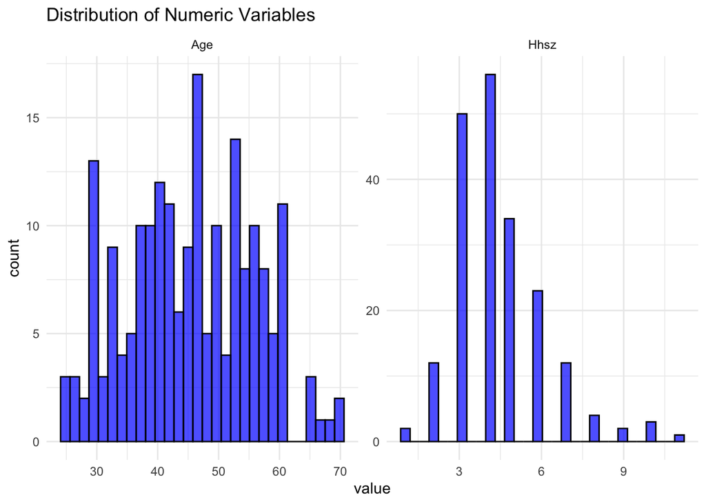

```r
# Plot histograms for numeric variables
numeric_vars <- c("Age", "Hhsz")
data %>% select(numeric_vars) %>%
  gather(key = "variable", value = "value") %>%
  ggplot(aes(x = value)) +
  geom_histogram(bins = 30, fill = "blue", color = "black", alpha = 0.7) +
  facet_wrap(~ variable, scales = "free") +
  theme_minimal() +
  labs(title = "Distribution of Numeric Variables")
```

The distribution analysis of numerical variables in the rice dataset, focusing on Age and Number of household members (Hhsz), reveals insights into the shape, center, and spread of the data.

### Univariate Analysis of Categorical Variables

*Distribution of Categorical Variables*

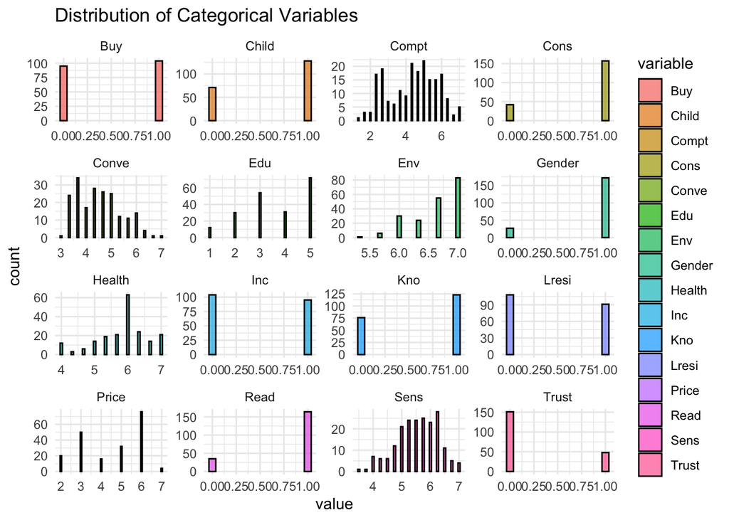

```r
# Plot bar plots for categorical variables
categorical_vars <- c("Gender", "Inc", "Edu", "Child", "Buy", "Kno", "Compt", "Sens", "Health", "Conve", "Price", "Lresi", "Trust", "Env", "Read", "Cons")
data %>% select(categorical_vars) %>%
  gather(key = "variable", value = "value") %>%
  ggplot(aes(x = value, fill = variable)) +
  geom_bar(position = "dodge", color = "black", alpha = 0.7) +
  facet_wrap(~ variable, scales = "free") +
  theme_minimal() +
  labs(title = "Distribution of Categorical Variables")
```

The distribution analysis of variables within the rice dataset reveals notable trends and insights into participants’ behaviors and attitudes towards certified rice consumption.

A significant portion of participants demonstrate regular purchasing behavior of certified rice, as evidenced by peaks in the distribution around 100 for those who purchased and lower values for those who did not. This indicates a potential market for certified rice products.

The distribution of participants having children under 15 years of age leans towards a higher proportion with children in this age group. This demographic factor may influence buying habits or consumption patterns, particularly regarding bulk purchases of rice.

Perceived competence in identifying certified rice tends to center around the 4-5 range, suggesting moderate confidence levels among participants. This highlights a potential opportunity for educational interventions to enhance participant certainty in identifying certified rice products.

Consumption patterns reveal that rice is considered an important daily staple for many participants, with a peak around 150. This underscores the significance of rice as a staple food within the diet of a substantial group of participants.

Convenience beliefs regarding certified rice exhibit variation, with some participants valuing convenience more highly than others. This diversity suggests the importance of tailored marketing strategies that address both preferences, emphasizing convenience benefits for some while focusing on other aspects like health or environmental impact for others.

The distribution of education levels within the dataset reflects diversity, with the majority falling within high school, higher education other than university, and university categories. This underscores the importance of considering participants’ educational backgrounds when designing communication or educational materials.

Awareness of environmental consequences associated with rice production varies among participants, highlighting the need for targeted interventions to raise awareness about the environmental impact of rice production choices.

The gender distribution shows a predominantly female representation within the dataset, indicating a gender imbalance among participants.

Beliefs regarding the health benefits of certified rice exhibit variation, with peaks around different values. This emphasizes the importance of understanding diverse perceptions when promoting certified rice, as some participants may prioritize health benefits more highly than others.

Income class distribution indicates a balance between upper-class and lower-income participants, suggesting a mix of income levels within the dataset.

A higher proportion of participants demonstrate objective knowledge of food quality certifications, indicating a level of familiarity and awareness among the participants.

Trust in food quality certification systems varies among participants, with some exhibiting high levels of trust while others express lower confidence. Understanding these variations can inform efforts to build trust and encourage participation in the certified rice market.

These observations depict diverse perspectives and behaviors regarding certified rice consumption.

### Bivariate Analysis (Numeric vs Numeric)

*Scatter plot of Age vs Household Size*

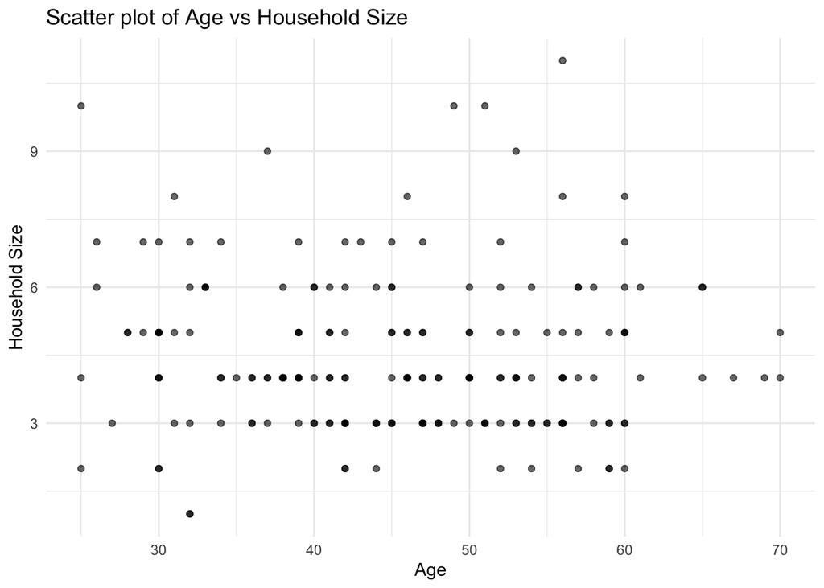

```r
# Scatter plot between Age and Hhsz
ggplot(data, aes(x = Age, y = Hhsz)) +
  geom_point(alpha = 0.6) +
  theme_minimal() +
  labs(title = "Scatter plot of Age vs Household Size",
       x = "Age",
       y = "Household Size")
```

### Bivariate Analysis (Numeric vs Categorical)

*Age Distribution by Purchase Behaviour*

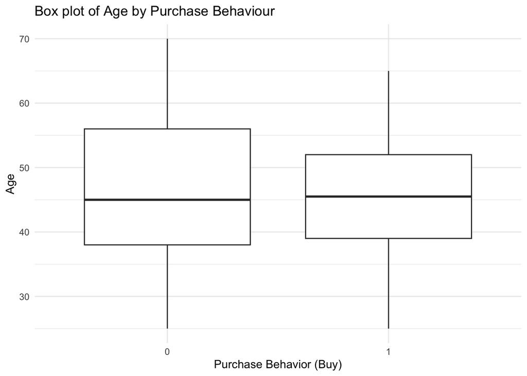

```r
# Box plot of Age by Buy
ggplot(data, aes(x = as.factor(Buy), y = Age)) +
  geom_boxplot() +
  theme_minimal() +
  labs(title = "Box plot of Age by Purchase Behaviour",
       x = "Purchase Behavior (Buy)",
       y = "Age")
```

The box plot shows the distribution of participant ages across two groups: those who buy certified rice (`Buy` = 1) and those who do not (`Buy` = 0).

While the median age is slightly lower for those who do not buy certified rice, the overall distribution indicates that certified rice is purchased by people across a variety of age groups. There is no strong separation between the two groups, suggesting that age may not be a defining factor when it comes to buying certified rice.

### Bivariate Analysis (Categorical vs Categorical)

```r
# Contingency table of Gender and Buy
table(data$Gender, data$Buy)
```

```
##
##      0  1
##   0 15 12
##   1 80 92
```

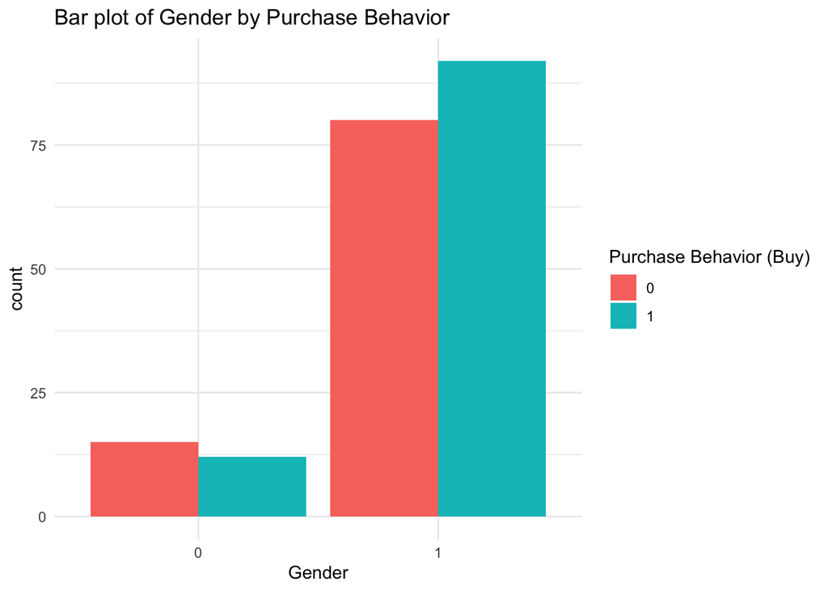

```r
# Bar plot of Gender by Buy
ggplot(data, aes(x = as.factor(Gender), fill = as.factor(Buy))) +
  geom_bar(position = "dodge") +
  theme_minimal() +
  labs(title = "Bar plot of Gender by Purchase Behavior",
       x = "Gender",
       fill = "Purchase Behavior (Buy)")
```

The bar plot indicates some associations between `Gender` and `Buy` . For instance, a higher proportion of females purchased certified rice compared to males.

### Correlation Matrix

```r
# Compute correlation matrix for numeric variables
numeric_data <- data %>% select(Age, Hhsz)
cor_matrix <- cor(numeric_data, use = "complete.obs")

# Print the correlation matrix
print(cor_matrix)
```

```
##              Age        Hhsz
## Age   1.00000000 -0.04438532
## Hhsz -0.04438532  1.00000000
```

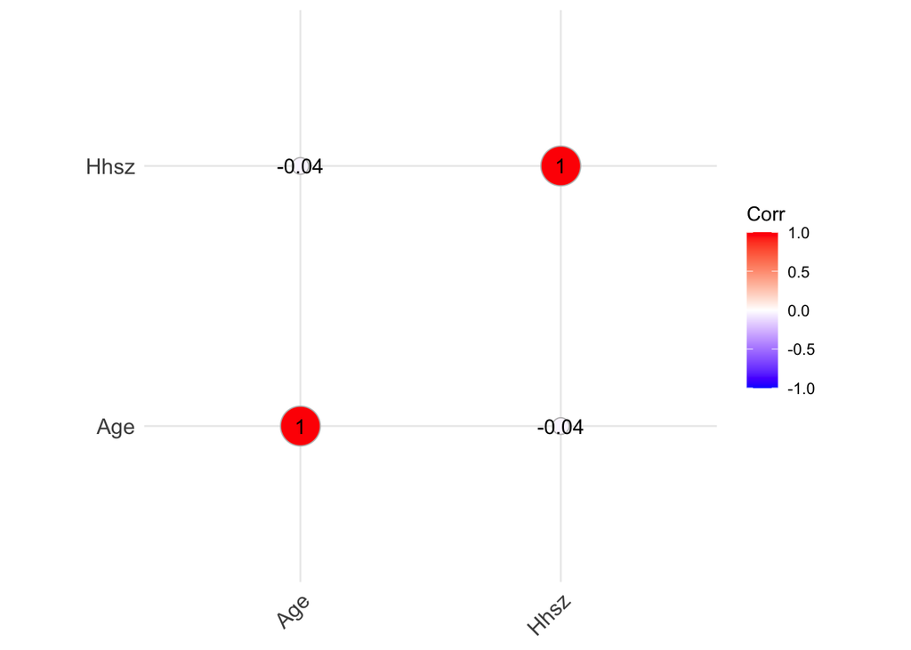

```r
# Visualize the correlation matrix
ggcorrplot(cor_matrix, method = "circle", lab = TRUE)
```

## Data Preprocessing

### Handling Missing Data

Following an assessment of missing values within the dataset, it was observed that the variables `Sens`, `Conve`, `Health`, and `Price` contained missing values. Specifically, `Health` exhibited two missing values, while `Sens`, `Conve`, and `Price` each had one missing value.

```r
# Define a function to calculate mode
get_mode <- function(x) {
  unique_x <- unique(x)
  unique_x[which.max(tabulate(match(x, unique_x)))]
}

# Imputation Strategy: Mode Imputation for categorical variables
imputed_values <- data %>%
  mutate(Sens = ifelse(is.na(Sens), get_mode(data$Sens), Sens),
         Conve = ifelse(is.na(Conve), get_mode(data$Conve), Conve),
         Health = ifelse(is.na(Health), get_mode(data$Health), Health),
         Price = ifelse(is.na(Price), get_mode(data$Price), Price))

# Combine imputed data with original dataset
combined_data <- cbind(data[, !names(data) %in% c("Sens", "Conve", "Health", "Price")],
                        imputed_values[, c("Sens", "Conve", "Health", "Price")])

# Drop old columns with missing values
cleaned_data <- combined_data %>%
  select(-matches("Sens|Conve|Health|Price"))

# View the cleaned dataset
head(cleaned_data)
```

```
##   ID Age Gender Inc Edu Child Hhsz Buy Kno Compt Lresi Trust  Env Read Cons
## 1  1  34      1   0   5     1    4   1   1  5.00     1     0 6.33    1    1
## 2  2  41      1   0   2     1    3   1   0  4.67     1     0 7.00    1    1
## 3  3  49      1   1   5     1   10   1   0  5.33     0     0 6.00    1    1
## 4  4  47      1   0   2     1    4   1   0  4.67     1     0 6.67    1    1
## 5  5  59      1   0   4     1    3   1   1  4.67     0     0 6.00    1    1
## 6  6  34      1   0   4     1    3   0   1  3.33     0     0 7.00    1    1
```

### Age Categorisation and Encoding

The `Age` variable in the dataset was categorised into four distinct age groups to facilitate analysis. These categories were then encoded numerically for ease of use in statistical analysis and machine learning models. The defined and encoded categories are as follows:

```r
# Define age categories and encode them
cleaned_data <- cleaned_data %>%
  mutate(Age_Category = cut(Age,
                            breaks = c(24, 34, 49, 64, Inf),
                            labels = c("Young Adults (25-34)", "Middle-aged Adults (35-49)", "Older Adults (50-64)", "Seniors (65+)"),
                            right = FALSE),
         Age_Category_Encoded = as.integer(factor(Age_Category,
                                                  levels = c("Young Adults (25-34)", "Middle-aged Adults (35-49)", "Older Adults (50-64)", "Seniors (65+)"))))

# View the first few rows to check the new Age_Category_Encoded column
head(cleaned_data)
```

```
##   ID Age Gender Inc Edu Child Hhsz Buy Kno Compt Lresi Trust  Env Read Cons
## 1  1  34      1   0   5     1    4   1   1  5.00     1     0 6.33    1    1
## 2  2  41      1   0   2     1    3   1   0  4.67     1     0 7.00    1    1
## 3  3  49      1   1   5     1   10   1   0  5.33     0     0 6.00    1    1
## 4  4  47      1   0   2     1    4   1   0  4.67     1     0 6.67    1    1
## 5  5  59      1   0   4     1    3   1   1  4.67     0     0 6.00    1    1
## 6  6  34      1   0   4     1    3   0   1  3.33     0     0 7.00    1    1
##                 Age_Category Age_Category_Encoded
## 1 Middle-aged Adults (35-49)                    2
## 2 Middle-aged Adults (35-49)                    2
## 3       Older Adults (50-64)                    3
## 4 Middle-aged Adults (35-49)                    2
## 5       Older Adults (50-64)                    3
## 6 Middle-aged Adults (35-49)                    2
```

### Drop Unnecessary Columns

In preparing the dataset for analysis, the `ID`, `Age`, and `Age_Category` columns were removed. This decision was made to streamline the dataset and focus on the variables that are most pertinent to the analysis objectives. The ID column, being a unique identifier for each participant, did not add analytical value. The `Age` and `Age_Category` columns were removed to avoid redundancy, given that the `Age_Category_Encoded` column now effectively captures the relevant age information in a numerical format suitable for analysis.

```r
# Drop ID, Age, and Age_Category columns
cleaned_data <- cleaned_data %>%
  select(-ID, -Age, -Age_Category)

# View the first few rows to check the updated dataset
head(cleaned_data)
```

```
##   Gender Inc Edu Child Hhsz Buy Kno Compt Lresi Trust  Env Read Cons
## 1      1   0   5     1    4   1   1  5.00     1     0 6.33    1    1
## 2      1   0   2     1    3   1   0  4.67     1     0 7.00    1    1
## 3      1   1   5     1   10   1   0  5.33     0     0 6.00    1    1
## 4      1   0   2     1    4   1   0  4.67     1     0 6.67    1    1
## 5      1   0   4     1    3   1   1  4.67     0     0 6.00    1    1
## 6      1   0   4     1    3   0   1  3.33     0     0 7.00    1    1
##   Age_Category_Encoded
## 1                    2
## 2                    2
## 3                    3
## 4                    2
## 5                    3
## 6                    2
```

### Feature Scaling of Hhsz

Feature scaling was applied to the `Hhsz` (number of household members) variable to standardise its values. This involved transforming the variable to have a mean of 0 and a standard deviation of 1. The standardised Hhsz variable, now represented as Hhsz_Scaled, ensures that the feature is on a similar scale as other variables in the dataset, which is crucial for many machine learning algorithms to perform effectively.

```r
# Standardize the Hhsz variable
cleaned_data <- cleaned_data %>%
  mutate(Hhsz_Scaled = scale(Hhsz)) %>%
  select(-Hhsz)  # Drop the original Hhsz column

# View the first few rows to check the updated dataset
head(cleaned_data)
```

```
##   Gender Inc Edu Child Buy Kno Compt Lresi Trust  Env Read Cons
## 1      1   0   5     1   1   1  5.00     1     0 6.33    1    1
## 2      1   0   2     1   1   0  4.67     1     0 7.00    1    1
## 3      1   1   5     1   1   0  5.33     0     0 6.00    1    1
## 4      1   0   2     1   1   0  4.67     1     0 6.67    1    1
## 5      1   0   4     1   1   1  4.67     0     0 6.00    1    1
## 6      1   0   4     1   0   1  3.33     0     0 7.00    1    1
##   Age_Category_Encoded Hhsz_Scaled
## 1                    2  -0.2547872
## 2                    2  -0.8375763
## 3                    3   3.2419474
## 4                    2  -0.2547872
## 5                    3  -0.8375763
## 6                    2  -0.8375763
```

### Feature Selection

Recursive Feature Elimination (RFE) was performed to identify the most important features influencing the purchase behavior of certified rice. Using cross-validation, the optimal subset of features was selected to improve the model’s predictive performance. Please refer to the output below.

```r
# Set up control for RFE
control <- rfeControl(functions=rfFuncs, method="cv", number=10)

# Define the predictor variables and the response variable
predictors <- cleaned_data[, !names(cleaned_data) %in% c("Buy")]
response <- cleaned_data$Buy

# Perform RFE
set.seed(123)
results <- rfe(predictors, response, sizes=c(1:ncol(predictors)), rfeControl=control)

# Print the results
print(results)
```

```
##
## Recursive feature selection
##
## Outer resampling method: Cross-Validated (10 fold)
##
## Resampling performance over subset size:
##
##  Variables   RMSE Rsquared    MAE  RMSESD RsquaredSD   MAESD Selected
##          1 0.4420   0.2472 0.3701 0.05112    0.13388 0.03912
##          2 0.4390   0.2442 0.3940 0.03993    0.12500 0.03501
##          3 0.4342   0.2740 0.3988 0.04267    0.18356 0.03557
##          4 0.4363   0.2774 0.4046 0.03742    0.17218 0.03095
##          5 0.4358   0.2756 0.4060 0.03211    0.13965 0.03037
##          6 0.4330   0.2679 0.3682 0.04593    0.11238 0.03586        *
##          7 0.4352   0.2574 0.3758 0.03742    0.10674 0.02923
##          8 0.4360   0.2547 0.3814 0.03926    0.12287 0.03068
##          9 0.4403   0.2430 0.3763 0.04379    0.12389 0.03293
##         10 0.4378   0.2518 0.3785 0.04514    0.12242 0.03511
##         11 0.4378   0.2470 0.3823 0.04085    0.10558 0.03213
##         12 0.4412   0.2341 0.3822 0.03829    0.09765 0.02966
##         13 0.4356   0.2527 0.3799 0.03932    0.10873 0.03162
##
## The top 5 variables (out of 6):
##    Compt, Inc, Lresi, Env, Gender
```

```r
# List the chosen features
chosen_features <- predictors[, predictors(results)]
print(chosen_features)
```

```
##     Compt Inc Lresi  Env Gender Trust
## 1    5.00   0     1 6.33      1     0
## 2    4.67   0     1 7.00      1     0
## 3    5.33   1     0 6.00      1     0
## 4    4.67   0     1 6.67      1     0
## 5    4.67   0     0 6.00      1     0
## 6    3.33   0     0 7.00      1     0
## 7    6.33   1     0 6.67      1     1
## 8    5.67   0     1 6.00      1     0
## 9    4.00   1     1 7.00      1     0
## 10   4.67   1     1 6.33      0     0
## 11   5.00   1     0 6.00      1     0
## 12   6.00   1     0 6.00      1     1
## 13   6.00   1     0 7.00      1     0
## 14   3.67   1     0 7.00      0     0
```

[output cut: 185 more lines]

## Model Implementation

### Data Preparation

The dataset used for model training and testing was preprocessed to select relevant features and split into training and testing sets. The target variable, ‘Buy,’ was extracted from the original cleaned data. Features were selected based on Recursive Feature Elimination (RFE) analysis, optimising model performance. The data was then split into 80% training and 20% testing sets using stratified sampling to ensure a balanced representation of classes.

```r
# Set the seed for reproducibility
set.seed(123)

# Extract the target variable 'Buy' from the original cleaned_data
response <- cleaned_data$Buy

# List the chosen features
chosen_features <- predictors[, results$optVariables]

# Add the target variable 'Buy' to the chosen features
chosen_features$Buy <- response

# Split the data into training and testing sets based on the chosen features
index <- createDataPartition(chosen_features$Buy, p = 0.8, list = FALSE)
train_data <- chosen_features[index, ]
test_data <- chosen_features[-index, ]
```

### Model Training

```r
# Combine chosen features with the response variable
final_data <- cbind(chosen_features, Buy = response)

# Set up the training control for 10-fold cross-validation
train_control <- trainControl(method = "cv", number = 10)

# Train the Random Forest model with 10-fold cross-validation
set.seed(123)
final_rf_model <- train(Buy ~ ., data = final_data, method = "rf", trControl = train_control, ntree = 100)

# Print the model summary
print(final_rf_model)
```

```
## Random Forest
##
## 199 samples
##   6 predictor
##
## No pre-processing
## Resampling: Cross-Validated (10 fold)
## Summary of sample sizes: 179, 179, 179, 179, 179, 179, ...
## Resampling results across tuning parameters:
##
##   mtry  RMSE       Rsquared   MAE
##   2     0.4186865  0.3058715  0.3588222
##   4     0.4213413  0.3061469  0.3368888
##   6     0.4199767  0.3164772  0.3320332
##
## RMSE was used to select the optimal model using the smallest value.
## The final value used for the model was mtry = 2.
```

```r
# Get variable importance
# Get variable importance
final_importance <- varImp(final_rf_model)
print(final_importance)
```

```
## rf variable importance
##
##        Overall
## Compt  100.000
## Inc     18.895
## Env     17.511
## Lresi    8.227
## Trust    1.938
## Gender   0.000
```

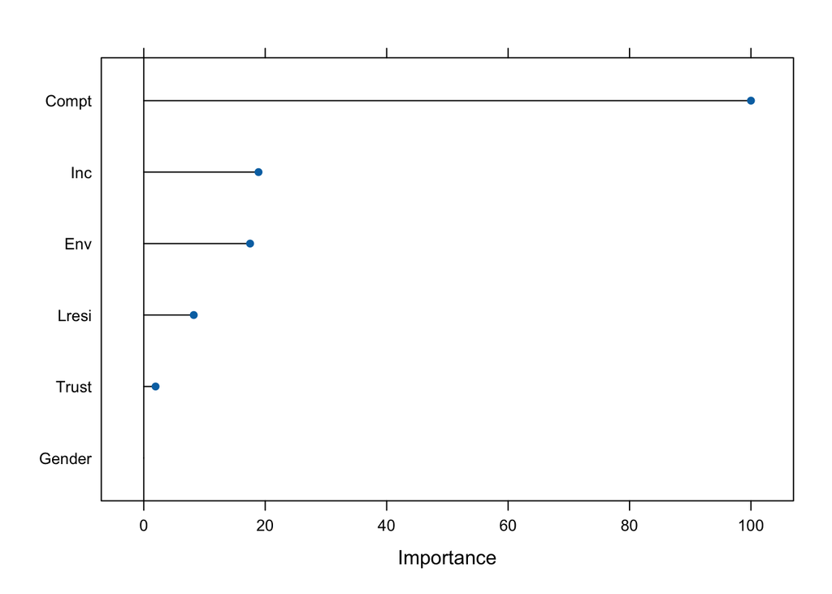

```r
plot(final_importance)
```

**Feature Importance Analysis:**

**Conclusion:** The analysis of feature importance highlights the significant role of perceived self-competence, income class, environmental perceptions and belief in reduced residues in predicting purchase behavior of certified rice.

### Model Evaluation

The trained Random Forest model was evaluated using various metrics to assess its performance. Variable importance analysis was conducted to identify the most influential features in predicting purchase behavior. The model’s overall performance was assessed using metrics such as accuracy, precision, recall, and F1-score.

```r
# Predict on the testing set
predictions <- predict(final_rf_model, newdata = test_data)

# Define a threshold
threshold <- 0.5

# Convert predictions to binary values
binary_predictions <- ifelse(predictions >= threshold, 1, 0)

# Ensure that both predicted and actual values are factors
binary_predictions <- factor(binary_predictions)
test_data$Buy <- factor(test_data$Buy)

# Evaluate the model with the confusion matrix
confusion_matrix <- confusionMatrix(binary_predictions, test_data$Buy)

# Print confusion matrix
print("Confusion Matrix:")
```

```
## [1] "Confusion Matrix:"
```

```r
print(confusion_matrix)
```

```
## Confusion Matrix and Statistics
##
##           Reference
## Prediction  0  1
##          0 16  5
##          1  1 17
##
##                Accuracy : 0.8462
##                  95% CI : (0.6947, 0.9414)
##     No Information Rate : 0.5641
##     P-Value [Acc > NIR] : 0.0001782
##
##                   Kappa : 0.6953
##
##  Mcnemar's Test P-Value : 0.2206714
##
##             Sensitivity : 0.9412
##             Specificity : 0.7727
##          Pos Pred Value : 0.7619
##          Neg Pred Value : 0.9444
##              Prevalence : 0.4359
##          Detection Rate : 0.4103
##    Detection Prevalence : 0.5385
##       Balanced Accuracy : 0.8570
##
##        'Positive' Class : 0
##
```

```r
# Additional metrics
accuracy <- confusion_matrix$overall['Accuracy']
precision <- confusion_matrix$byClass['Pos Pred Value']
recall <- confusion_matrix$byClass['Sensitivity']
f1 <- confusion_matrix$byClass['F1']
print(paste("Accuracy:", accuracy))
```

```
## [1] "Accuracy: 0.846153846153846"
```

```r
print(paste("Precision:", precision))
```

```
## [1] "Precision: 0.761904761904762"
```

```r
print(paste("Recall:", recall))
```

```
## [1] "Recall: 0.941176470588235"
```

```r
print(paste("F1-score:", f1))
```

```
## [1] "F1-score: 0.842105263157895"
```

**Confusion Matrix and Performance Metrics:** The confusion matrix provides a snapshot of the model’s performance in predicting the purchase behavior of certified rice.

- **Accuracy:** The model achieved an accuracy of 84.62%, indicating the proportion of correctly classified instances out of the total predictions.
- **Precision:** The precision, also known as the positive predictive value, stands at 76.19%. This metric represents the proportion of true positive predictions out of all positive predictions made by the model.
- **Recall (Sensitivity):** The recall, or sensitivity, measures the proportion of actual positive instances that were correctly identified by the model. It is calculated at 94.12%.
- **F1-score:** The F1-score, a harmonic mean of precision and recall, serves as a combined measure of the model’s accuracy and completeness. The F1-score achieved by the model is 84.21%.

### ROC Curve Analysis

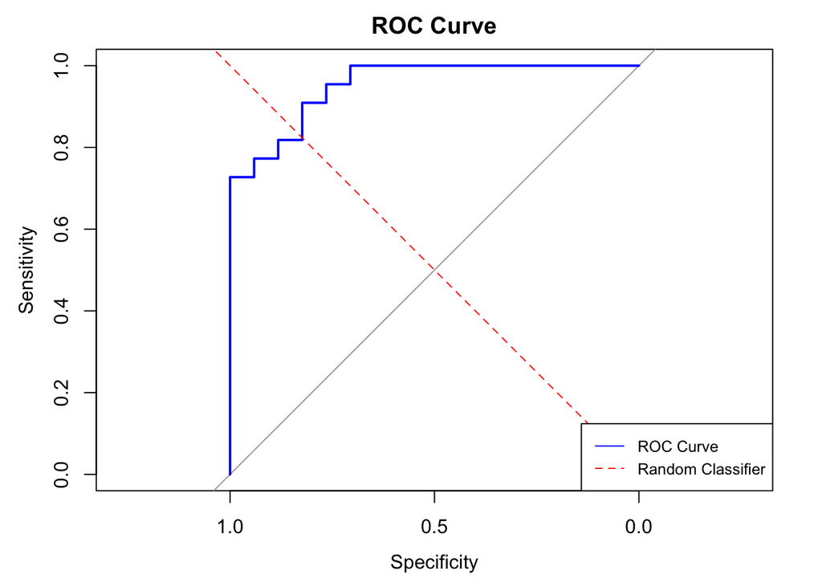

```r
# Plot ROC curve with reversed x-axis
roc_curve <- roc(test_data$Buy, as.numeric(predictions))
plot(roc_curve, main="ROC Curve", col="blue", lwd=2, reverse=TRUE)

# Add diagonal line (random classifier)
abline(a=0, b=1, lty=2, col="red")

# Add legend
legend("bottomright", legend=c("ROC Curve", "Random Classifier"), col=c("blue", "red"), lty=1:2, cex=0.8)
```

```r
# Calculate AUC (Area Under the Curve)
auc <- auc(roc_curve)
print(paste("AUC:", auc))
```

```
## [1] "AUC: 0.951871657754011"
```

**ROC Curve Results**

**Key Findings:** The ROC curve analysis for the classifier yielded an Area Under the Curve (AUC) of 0.9519. The AUC is a measure of the classifier’s ability to distinguish between positive and negative classes.

**Interpretation:** An AUC of 0.9519 indicates that the classifier possesses a strong discriminative power in distinguishing between the positive and negative classes. This value suggests that the classifier performs very well in terms of identifying true positive instances while minimizing false positive instances.

**Implications:** The high AUC value of 0.9519 demonstrates that the classifier is highly effective in differentiating between the classes. This strong performance implies that the model is well-calibrated and reliable for predicting the purchase behavior of certified rice. While there is always room for fine-tuning, the current model shows excellent discriminative ability, making it a robust tool for this task.

**Conclusion:** The AUC of 0.9519 suggests that the classifier has a very high discriminative power. This indicates that the model is highly effective and reliable in predicting the purchase behavior of certified rice, showcasing the success of the current model’s optimization and feature engineering efforts.

## SHAP Values Analysis (SHAP (SHapley Additive exPlanations))

SHAP values offered insights into the importance of features in driving model predictions. By calculating the contribution of each feature to the model’s output, SHAP values highlighted the factors influencing purchase behavior. In our analysis, we utilized the Kernel SHAP method to compute SHAP values for the Random Forest model. The SHAP visualization (shapviz) provided a clear understanding of feature importance through various plots, such as bee swarm plots, which visualised the distribution of SHAP values for each feature. Insights gained from SHAP analysis could inform marketing strategies and enhance understanding of customer preferences.

```r
# Train the Random Forest model on the training set
final_rf_model <- randomForest(Buy ~ ., data = train_data, ntree = 100)

# Calculate Kernel SHAP values
library(kernelshap)
s <- kernelshap(final_rf_model, train_data[, -which(names(train_data) == "Buy")], bg_X = train_data)
```

```
## Exact Kernel SHAP values
```

[output not shown]

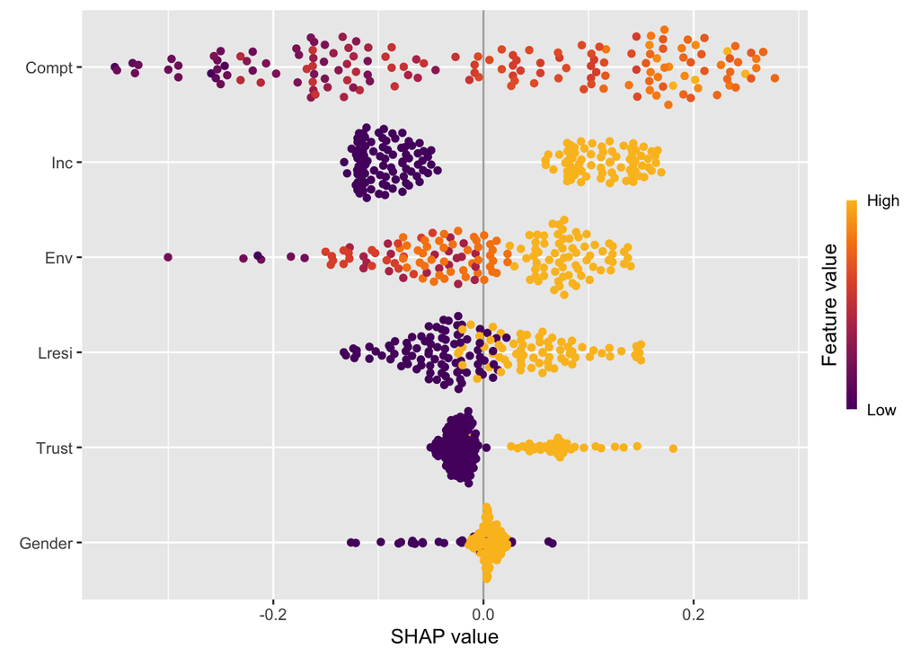

```r
# Convert to shapviz object
library(shapviz)
sv <- shapviz(s)

# Gain insights
sv_importance(sv, kind = "bee")
```

**Purpose:** Analysing the SHAP values helps us understand how important different factors (features) are in predicting rice purchase behavior.

# Conclusion

The primary objective of this analysis was to identify key factors influencing the likelihood of buying certified rice using a Random Forest model. Our findings highlight the significant roles of various features, with Competence (perceived self-competence in identifying certified rice) emerging as the most influential factor. Income, Environment, `Lresi` (belief in reduced residues), and Trust in the certification system also play notable roles.

The Random Forest model, validated through 10-fold cross-validation, demonstrated high accuracy (84.62%) and a balanced accuracy score of 85.70%, indicating strong discriminative power. The ROC curve analysis, with an AUC of 0.9519, further confirmed the model’s excellent performance.

SHAP values provided deeper insights into feature importance, revealing how individual attributes impacted model predictions. These insights can guide targeted strategies to enhance the model’s predictive accuracy and practical application.

This analysis demonstrates the importance of understanding feature impacts in predictive modeling, offering a robust foundation for predicting consumer behavior towards certified rice. The results indicate that the current model is highly effective.